# Vorwärtsschnitt mittels orientierter Wegbeschreibung

Oliver Fritz

## Aufgabenstellung

```r
# Hier die Parameter des Vorwärtsschnitts einfügen/anpassen:

P1 <- c(176678, 9783668)
P2 <- c(178956, 9783624)
alpha1 <- 13.73998
alpha2 <- 15.12171

angle_unit <- "gon" # Optionen: "deg" | "rad" | "gon" bzw. "grad"
orientation <- "cartesian" # Optionen: "geodetic" | "cartesian"
```

Gegeben seien die *kartesischen* Koordinaten der Punkte $P_1=\binom{176678}{9783668}$ und $P_2=\binom{178956}{9783624}$ sowie die Richtungswinkel $\alpha_1=13.73998\text{ gon}$ und $\alpha_2=15.12171\text{ gon}$. Man bestimme die Lage und die Koordinaten des Punktes $P_3$!

## Benötigte Erweiterungen

```r
source("MatheGIS.R")
```

## Graphische Darstellung

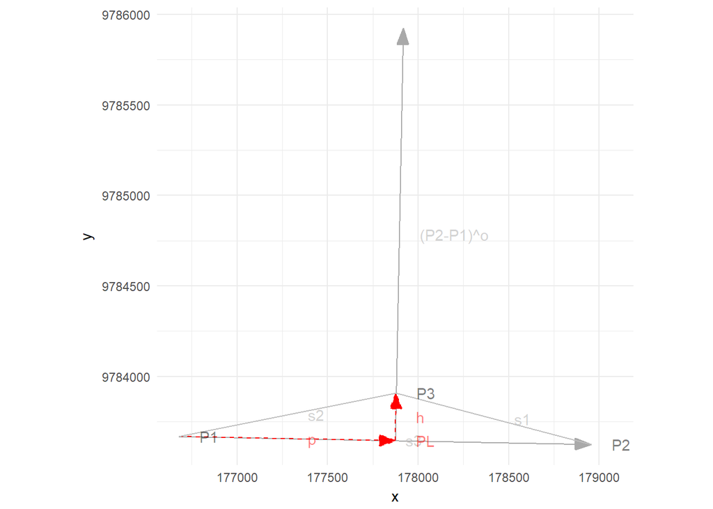

```r
plot_vorwaertsschnitt(P1=P1, P2=P2, alpha1=alpha1, alpha2=alpha2, angle_unit=angle_unit, orientation=orientation)
```

## Lösung

### Lage

```r
quadrant <- quadrant_P3(alpha1, angle_unit)
```

Aus dem Wert des Richtungswinkels $\alpha_1=13.73998\text{ gon}$ kann geschlossen werden, dass sich $P_3$ im **I. Quadranten** befindet:

### Berechnung

Die Lösung des Vorwärtsschnitts mittels orientierter Wegbeschreibung hat zunächst folgende Form:
$$P_3=P_1+\frac{p}{s_3}(P_2-P_1)+\frac{h}{s_3}(P_2-P_1)^{\circ}$$
Da $\frac{p}{s_3}=\frac{\cot\alpha_1}{\cot\alpha_1+\cot\alpha_2}$ und $\frac{h}{s_3}=\frac{1}{\cot\alpha_1+\cot\alpha_2}$, kann man den Höhenabschnitt $p$, die Höhe $h$ und die Strecke $s_3$ durch Einsetzen aus der Gleichung entfernen und erhält nach Ausklammern:
$$P_3=P_1+\frac{1}{\cot\alpha_1+\cot\alpha_2}(\cot\alpha_1(P_2-P_1)+(P_2-P_1)^{\circ})$$

### Bestimmung der Koordinaten des Punktes $P_3$

Nun können mittels der Formel für den Vorwärtsschnitt die Koordinaten des Punktes $P_3$ bestimmt werden.

```r
P3 <- vorwaertsschnitt_P3(P1=P1, P2=P2, alpha1=alpha1, alpha2=alpha2, angle_unit=angle_unit)
```

$$\begin{equation}
\begin{split}
P_3&=P_1+\frac{1}{\cot\alpha_1+\cot\alpha_2}(\cot\alpha_1(P_2-P_1)+(P_2-P_1)^{\circ})\\\\
&\approx\binom{176678}{9783668}+\frac{1}{4.5612+4.1305}(4.5612\binom{178956-176678}{9783624-9783668}+\binom{-(9783624-9783668)}{178956-176678})\\\\
&\approx\binom{177878.5}{9783907}
\end{split}
\end{equation}$$

Der Punkt $P_3$ hat die x-Koordinate 177878.5 und die y-Koordinate 9783907.